# Code-Through - Harb

Brittany Harb

10 October, 2020

## Song Lyrics

For my final code-through, I thought I would practice some more text analysis and maybe some text visualization. I found this dataset on kaggle to use: https://www.kaggle.com/terminate9298/songs-lyrics?select=lyrics.csv.

Here is a sample of the data:

```r
 head(lyrics) %>% pander(1)
```

1 (continued below)

| X | link | artist |
| --- | --- | --- |
| 0 | ../lyrics/backstreetboys/climbingthewalls.html | Backstreet Boys Lyrics |
| 1 | ../lyrics/westlife/howtobreakaheart.html | Westlife Lyrics |
| 2 | ../lyrics/deanmartin/iwill.html | Dean Martin Lyrics |
| 3 | ../lyrics/deanmartin/tellyourmotherhello.html | Dean Martin Lyrics |
| 4 | ../lyrics/deanmartin/behonestwithme.html | Dean Martin Lyrics |
| 5 | ../lyrics/deanmartin/myriflemyponyandme.html | Dean Martin Lyrics |

| song_name | lyrics |
| --- | --- |
| Climbing The Walls | [Brian:] Close your eyes, make a wish That this could last forever If only you could stay with me now So tell me what it is That keeps us from each other now Yeah it’s coming to get me You’re under my… |
| How To Break A Heart | Since you’re not worth my love I haven’t given up I’m stronger than that (I’m stronger than that) And though my heart will break I’m takin’ back my faith Cos right now my world is spinnin’ too fast Bu… |
| I Will | I don’t want to be the one to say I’m gonna miss you but I will I don’t want to say I’m gonna cry my eyes out baby but I will I’m not ashamed for you to know how much I really love you so Cuz it was s… |
| Tell Your Mother Hello | Sure I loved the dear money that shines in her hair And the brow that’s all furrowed and wrinkled with care I kissed the dear fingers that hold all that dough Oh God bless her and keep her Tell your m… |
| Be Honest With Me | Be honest with me dear whatever you do Remember you’re mine dear so always be true Where ever you wander on land or on sea If you really love me be honest with me My poor heart would break dear if you… |
| My Rifle, My Pony And Me | The sun is sinking in the west The cattle go down to the stream The redwing settles in the nest It’s time for a cowboy to dream Purple light in the canyons That’s where I long to be With my three good… |

It is a bit long because the entire song is typed into the dataset.

Here I am just placing some ode to clean up the data a little bit.

```r
lyrics$lyrics <- gsub( " ", " ", lyrics$lyrics )
lyrics$lyrics <- gsub( "\\s", " ", lyrics$lyrics )
lyrics$lyrics <- gsub( "[[:punct:]]", "", lyrics$lyrics )   # remove punctuation
lyrics$lyrics <- gsub( "&nbsp;", "", lyrics$lyrics )# remove nonbreaking spaces
lyrics$song_name <- tolower(lyrics$song_name)
song_name_word <- strsplit(lyrics$song_name, " ")
song_name_word <- unlist(song_name_word)

head(song_name_word)
```

```
## [1] "climbing" "the"      "walls"    "how"      "to"       "break"
```

First I am going to look at a sample of the most commonly used words in songs for the entire dataset.

```r
lower.lyrics <- tolower( lyrics$lyrics ) # convert to lower case

words <- strsplit( lower.lyrics, " " )
t <- table( unlist( words ) )

t %>%
  sort() %>%
  tail( 25 ) %>%
  pander()
```

Table continues below

| just | for | but | know | so | is | on | all | be | im | your |
| --- | --- | --- | --- | --- | --- | --- | --- | --- | --- | --- |
| 2669 | 2731 | 2799 | 2821 | 2933 | 2972 | 3178 | 3354 | 3396 | 3652 | 3739 |

Table continues below

| of | love | that | in | it | my | me | a | to | and | the |
| --- | --- | --- | --- | --- | --- | --- | --- | --- | --- | --- |
| 3908 | 3960 | 4380 | 5154 | 5448 | 5992 | 7461 | 7545 | 8900 | 9406 | 13645 |

| i | you |  |
| --- | --- | --- |
| 16283 | 17584 | 23234 |

Now I am going to use lapply to count the number of words in the songs. I’m only going to count the first six, only because I want to show the function, and I’d rather not have a whole sheet of numbers.

```r
first.six.songs <- head( lyrics$lyrics )
word.list  <- strsplit( first.six.songs , " " )

word.count <- lapply( word.list, length )

word.count <- unlist( word.count )         # convert to a vector
word.count
```

```
## [1] 326 342 203  45 112 155
```

There is a lot of variance in the number of words in songs!

Now we are going to build a word cloud! For this I’m going to look at the song titles, as they will be more telling I think of the nature of the songs. First we are going to use Corpus() from the text mining package. I found this website to be very instructional: http://www.sthda.com/english/wiki/text-mining-and-word-cloud-fundamentals-in-r-5-simple-steps-you-should-know#:~:text=The%20procedure%20of%20creating%20word,keywords%20as%20a%20word%20cloud.

```r
docs <- Corpus(VectorSource(song_name_word))


dtm <- TermDocumentMatrix(docs)
m <- as.matrix(dtm)
v <- sort(rowSums(m),decreasing=TRUE)
d <- data.frame(word = names(v),freq=v)
head(d, 10)
```

|  | word | freq |
| --- | --- | --- |
| you | you | 1602 |
| yeah | yeah | 1365 |
| the | the | 1009 |
| i'm | i'm | 580 |
| and | and | 574 |
| love | love | 550 |
| baby | baby | 424 |
| know | know | 351 |
| don't | don't | 317 |
| that | that | 304 |

Now that all of the background stuff is done, we are goinf to make the cloud! Woohoo!

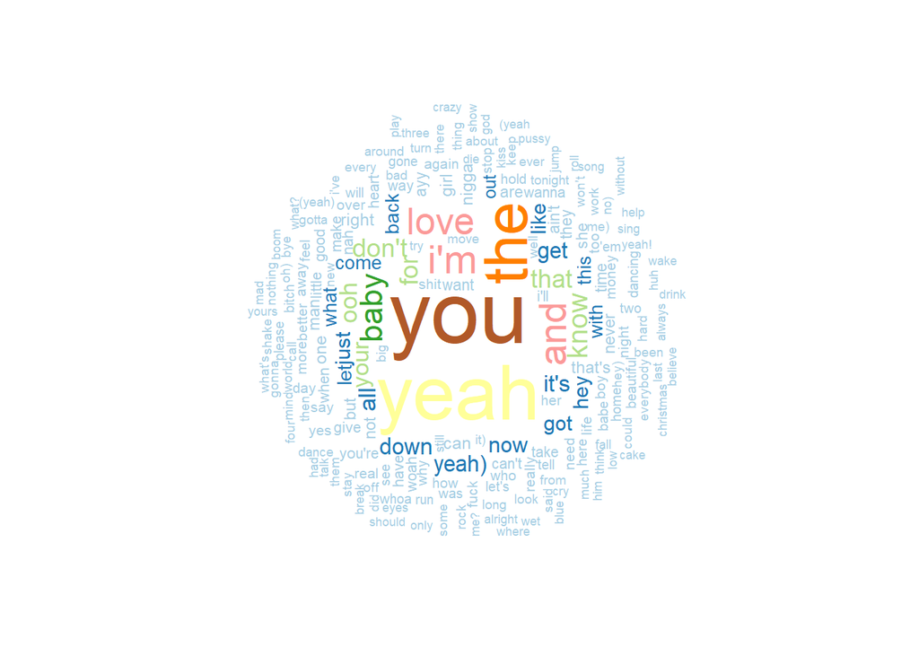

```r
set.seed(12345)
wordcloud(words = d$word, freq = d$freq, min.freq = 20,
          max.words=200, random.order=FALSE, rot.per=0.6,
          colors=brewer.pal(12, "Paired"))
```

So there it is! I didn’t want to do anything too crazy, just practicing some more text analysis and making a word cloud of the most used words in song titles! I hope you enjoyed this little code-through!